# Simulation Studies Based on ACTG175

Adapting the ForestSearch GBSG Simulation Framework to HIV Clinical Trial Data

Author

Larry F. Leon

Published

April 4, 2026

# 1 Introduction

## 1.1 Motivation

Leon et al. (2024) demonstrated the ForestSearch methodology using the German Breast Cancer Study Group (GBSG) dataset (`survival::gbsg`) as both the applied analysis target and the covariate template for simulation studies. The `setup_gbsg_dgm()` convenience function encodes all GBSG-specific preparation choices — variable discretisation, subgroup definition, Weibull calibration — into a single reproducible call.

This document adapts the same simulation framework to the **AIDS Clinical Trials Group Study 175** (ACTG175) dataset from the `speff2trial` package. ACTG175 is a randomised trial of four antiretroviral regimens in HIV-infected subjects (Hammer et al., *NEJM* 1996). The adaptation serves two purposes:

1. **Methodological validation**: confirming that the ForestSearch operating characteristics (detection rate, sensitivity, specificity, PPV) generalise beyond the GBSG breast cancer setting to a different disease, population, endpoint structure, and covariate set.
2. **Template for new-dataset simulations**: demonstrating the recommended workflow when `setup_gbsg_dgm()` is not appropriate and the analyst must use `generate_aft_dgm_flex()` directly.

## 1.2 Adaptation Checklist

To substitute your own trial data for ACTG175, you must address each of the following steps. The sections that follow implement each one for ACTG175; cross-references are provided so you can see the concrete implementation alongside each checklist item.

| Step | What to do | Section |
| --- | --- | --- |
| **1. Load your data** | Create `id`, `y` (observed time), `event` (0/1 indicator), and `treat` (0 = control, 1 = treatment) columns. Time units for `y` set the time scale for the entire simulation. | Section 2 |
| **2. Choose confounders** | Identify the candidate variables for the subgroup search. These become `factor_vars` in the DGM and `confounders_base` in the simulation. | Section 2 |
| **3. Discretise continuous variables** | Create binary `z1`, `z2`, … columns from continuous covariates. Document your cutpoint rationale (see Section 1.3). | Section 2 |
| **4. Define the harm subgroup** | Set `dgm_subgroup_vars` and `dgm_subgroup_cuts` consistently with your factor coding. Verify with an explicit `stopifnot()` check. | Section 3 |
| **5. Set time-scale parameters** | Ensure `sim_analysis_time` is in the same units as your outcome variable. Run the time-scale diagnostic after DGM creation. | Section 3 |
| **6. Update `cox_formula_adj`** | Include confounders appropriate for your study. The formula must use simulated column names (`y_sim`, `event_sim`, `treat_sim`). | Setup chunk |
| **7. Update `confounders_base`** | This must list all `z*` variable names passed to ForestSearch and GRF. It must match `factor_vars` in the DGM call. | Section 5 |
| **8. Calibrate `k_inter`** | Run the grid search targeting a clinically meaningful HR(H). | Section 3.3 |
| **9. Run time-scale diagnostic** | Verify `exp(dgm$model_params$mu)` is close to your observed median event time. | Section 3.2.1 |
| **10. Run censoring diagnostic** | Use `check_censoring_dgm()` to compare simulated vs observed censoring. | Section 4.1 |
| **11. Set simulation count** | Use $\geq 500$ replicates for stable operating characteristics. | Section 5 |

## 1.3 Choosing Discretisation Cutpoints

ForestSearch operates on binary (factor) covariates. Continuous variables must be discretised before building the DGM. There are three common strategies:

1. **Clinical cutpoints** — use thresholds defined by domain knowledge (e.g., CD4 $< 200$ cells/mm³ for AIDS-defining immunosuppression). Preferred when available.
2. **Data-driven medians** — split at the sample median; appropriate when no clinical threshold exists. Used here for `z3` (Karnofsky performance score) and `z4` (CD4 baseline count).
3. **GRF-guided splits** — run a preliminary GRF analysis on the observed data (`grf::causal_forest()`) to identify the variable-importance-weighted split points that maximise treatment effect heterogeneity. This was the approach for `z1` (age $\leq 34$) and `z5` (CD8 $> 1292$), derived from the analysis in `actg175_analysis_v1.Rnw`.

For your own dataset, we recommend starting with strategy (1) where available, falling back to (2), and optionally using (3) as a sensitivity analysis. Whichever approach you choose, document the rationale alongside the cutpoint value in your setup chunk.

## 1.4 Steps for Swapping GBSG with ACTG175

Replacing the GBSG template with ACTG175 requires changes at every stage of the simulation pipeline. The table below summarises each change; subsequent sections implement them in detail.

[output not shown]

The subgroup definition for ACTG175 is derived from the GRF screening analysis in `actg175_analysis_v1.Rnw`, which identified age $\leq 34$ and CD8 count $> 1292$ as the primary splits delineating a subgroup recommended for control (i.e., potential harm from the experimental treatment).

# 2 Side-by-Side Dataset Comparison

```r
library(forestsearch)
library(survival)
library(speff2trial)
library(data.table)
library(ggplot2)
library(patchwork)
library(gt)
library(foreach)
library(doFuture)
library(future)
```

## 2.1 Loading and Preparing Both Datasets

The code below prepares both datasets for the simulation framework. For each dataset, the key steps are:

1. Create a standardised outcome variable (`y`) in the dataset’s natural time units.
2. Create a binary treatment indicator (`treat`: 0 = control, 1 = treatment).
3. Discretise continuous covariates into binary factors (`z1`, `z2`, …) using the cutpoints defined in the setup chunk.
4. Construct the true harm-subgroup indicator (`flag_harm`) using the same variables and levels specified in `dgm_subgroup_vars` and `dgm_subgroup_cuts`.

```r
# ── GBSG ──────────────────────────────────────────────────────
gbsg_df        <- survival::gbsg
gbsg_df$y      <- gbsg_df$rfstime / 30.4375
gbsg_df$treat  <- gbsg_df$hormon

er_cut         <- quantile(gbsg_df$er, probs = gbsg_er_quantile)
gbsg_df$z1     <- as.factor(ifelse(gbsg_df$er <= er_cut, 1L, 0L))
gbsg_df$z3     <- as.factor(ifelse(gbsg_df$meno == 0, 1L, 0L))
gbsg_df$flag_harm <- as.integer(gbsg_df$z1 == 1 & gbsg_df$z3 == 1)

# ── ACTG175 ───────────────────────────────────────────────────
actg_df        <- subset(speff2trial::ACTG175, arms %in% actg_arms)
actg_df$id     <- seq_len(nrow(actg_df))
actg_df$time_days <- actg_df$days
actg_df$treat  <- ifelse(actg_df$arms == actg_treat_arm, 1L, 0L)

# ── Discretise continuous variables into binary factors ───────
# Each variable is coded so that 1 = condition satisfied.
# For example, z1 = 1 means the patient is young (age <= cutpoint).
#
# Subgroup-defining variables (from GRF screening):
# z1: age <= actg_age_cut  (subgroup factor 1)
actg_df$z1  <- as.factor(ifelse(actg_df$age  <= actg_age_cut,  1L, 0L))
# z2: weight <= actg_wtkg_cut (prognostic)
actg_df$z2  <- as.factor(ifelse(actg_df$wtkg <= actg_wtkg_cut, 1L, 0L))
# z3: Karnofsky <= median (data-driven cutpoint)
actg_df$z3  <- as.factor(ifelse(
  actg_df$karnof <= median(actg_df$karnof), 1L, 0L
))
# z4: CD4 baseline <= median (data-driven cutpoint)
actg_df$z4  <- as.factor(ifelse(
  actg_df$cd40 <= median(actg_df$cd40), 1L, 0L
))
# z5: CD8 > actg_cd80_cut  (subgroup factor 2)
actg_df$z5  <- as.factor(ifelse(actg_df$cd80 > actg_cd80_cut,  1L, 0L))
# z6-z12: binary indicators (passed through as-is from the dataset)
actg_df$z6  <- as.factor(actg_df$hemo)
actg_df$z7  <- as.factor(actg_df$homo)
actg_df$z8  <- as.factor(actg_df$drugs)
actg_df$z9  <- as.factor(actg_df$race)
actg_df$z10 <- as.factor(actg_df$gender)
actg_df$z11 <- as.factor(actg_df$oprior)
actg_df$z12 <- as.factor(actg_df$symptom)

# ── Factor coding summary ──────────────────────────────────────
# z1  = 1 => age <= 34         (young)
# z2  = 1 => weight <= 75 kg   (low weight)
# z3  = 1 => Karnofsky <= median (lower performance)
# z4  = 1 => CD4 <= median     (lower baseline CD4)
# z5  = 1 => CD8 > 1292        (high CD8)
# z6  = 1 => hemophilia yes
# z7  = 1 => homosexual activity yes
# z8  = 1 => IV drug use yes
# z9  = 1 => non-white
# z10 = 1 => male
# z11 = 1 => prior antiretroviral yes
# z12 = 1 => symptomatic yes

# ── Harm subgroup: z1 = 1 AND z5 = 1 ──────────────────────────
# This must match dgm_subgroup_vars / dgm_subgroup_cuts exactly.
actg_df$flag_harm <- as.integer(
  actg_df[[dgm_subgroup_vars[1]]] == dgm_subgroup_cuts[[dgm_subgroup_vars[1]]] &
  actg_df[[dgm_subgroup_vars[2]]] == dgm_subgroup_cuts[[dgm_subgroup_vars[2]]]
)

# Verify subgroup definition matches expectations
stopifnot(
  identical(dgm_subgroup_vars, c("z1", "z5")),
  identical(dgm_subgroup_cuts, list(z1 = 1L, z5 = 1L))
)
cat(sprintf(
  "Harm subgroup H: z1 == 1 (age <= %d) AND z5 == 1 (CD8 > %d)\n",
  actg_age_cut, actg_cd80_cut
))
```

```
#> Harm subgroup H: z1 == 1 (age <= 34) AND z5 == 1 (CD8 > 1292)
```

```r
cat(sprintf(
  "  H prevalence: %d / %d (%.1f%%)\n",
  sum(actg_df$flag_harm), nrow(actg_df),
  100 * mean(actg_df$flag_harm)
))
```

```
#>   H prevalence: 106 / 1046 (10.1%)
```

## 2.2 Structural Comparison

```r
comp <- data.frame(
  Feature = c(
    "Disease area",
    "Trial name",
    "R package",
    "Total N (used)",
    "Treatment arms",
    "Outcome",
    "Time unit",
    "Median follow-up",
    "Event rate",
    "Treatment effect (ITT HR)",
    "Subgroup definition (H)",
    "H prevalence",
    "N confounders (binary)",
    "Confounder types"
  ),
  GBSG = c(
    "Breast cancer",
    "German Breast Cancer Study Group",
    "survival::gbsg",
    sprintf("%d", nrow(gbsg_df)),
    "Hormonal therapy vs. control",
    "Recurrence-free survival",
    "Months",
    sprintf("%.1f months", median(gbsg_df$y)),
    sprintf("%.0f%%", 100 * mean(gbsg_df$status)),
    sprintf("%.3f", exp(coef(coxph(
      Surv(y, status) ~ treat, data = gbsg_df
    )))),
    sprintf("ER-low (Q%d) AND premenopausal",
            as.integer(gbsg_er_quantile * 100)),
    sprintf("%.0f%%", 100 * mean(gbsg_df$flag_harm)),
    "7",
    "All pre-discretised from continuous/categorical"
  ),
  ACTG175 = c(
    "HIV / AIDS",
    "AIDS Clinical Trials Group Study 175",
    "speff2trial::ACTG175",
    sprintf("%d", nrow(actg_df)),
    "Didanosine (ddI) vs. zidovudine (ZDV)",
    "Time to >= 50% CD4 decline, AIDS, or death",
    "Days",
    sprintf("%.0f days", median(actg_df$time_days)),
    sprintf("%.0f%%", 100 * mean(actg_df$cens)),
    sprintf("%.3f", exp(coef(coxph(
      Surv(time_days, cens) ~ treat, data = actg_df
    )))),
    sprintf("Age <= %d AND CD8 > %d", actg_age_cut, actg_cd80_cut),
    sprintf("%.0f%%", 100 * mean(actg_df$flag_harm)),
    "12",
    "Mix of binary indicators and discretised continuous"
  ),
  check.names = FALSE,
  stringsAsFactors = FALSE
)

gt(comp) |>
  tab_header(
    title = "Dataset Comparison: GBSG vs ACTG175"
  ) |>
  cols_label(Feature = "") |>
  tab_style(
    style = cell_text(weight = "bold"),
    locations = cells_body(columns = Feature)
  ) |>
  tab_style(
    style = cell_fill(color = "#F5F5F5"),
    locations = cells_body(rows = seq(1, nrow(comp), by = 2))
  )
```

Side-by-side comparison of GBSG and ACTG175 datasets

Dataset Comparison: GBSG vs ACTG175

|  | GBSG | ACTG175 |
| --- | --- | --- |
| Disease area | Breast cancer | HIV / AIDS |
| Trial name | German Breast Cancer Study Group | AIDS Clinical Trials Group Study 175 |
| R package | survival::gbsg | speff2trial::ACTG175 |
| Total N (used) | 686 | 1046 |
| Treatment arms | Hormonal therapy vs. control | Didanosine (ddI) vs. zidovudine (ZDV) |
| Outcome | Recurrence-free survival | Time to >= 50% CD4 decline, AIDS, or death |
| Time unit | Months | Days |
| Median follow-up | 35.6 months | 1013 days |
| Event rate | 44% | 20% |
| Treatment effect (ITT HR) | 0.695 | 0.937 |
| Subgroup definition (H) | ER-low (Q25) AND premenopausal | Age <= 34 AND CD8 > 1292 |
| H prevalence | 12% | 10% |
| N confounders (binary) | 7 | 12 |
| Confounder types | All pre-discretised from continuous/categorical | Mix of binary indicators and discretised continuous |

## 2.3 Confounder Mapping

```r
conf_map <- data.frame(
  Role = c(
    "Subgroup factor 1",
    "Subgroup factor 2",
    "Prognostic 1",
    "Prognostic 2",
    "Prognostic 3",
    "Prognostic 4",
    "Prognostic 5",
    "Demographic 1",
    "Demographic 2",
    "Demographic 3",
    "Demographic 4",
    "Demographic 5"
  ),
  `GBSG variable` = c(
    sprintf("z1: ER <= Q%d", as.integer(gbsg_er_quantile * 100)),
    "z3: premenopausal",
    "z2: age <= median",
    "z4: PgR <= median",
    "z5: nodes <= median",
    "v6: tumour size <= median",
    "v7: grade = 3",
    rep("---", 5)
  ),
  `ACTG175 variable` = c(
    sprintf("z1: age <= %d", actg_age_cut),
    sprintf("z5: CD8 > %d", actg_cd80_cut),
    sprintf("z2: weight <= %d kg", actg_wtkg_cut),
    "z3: Karnofsky <= median",
    "z4: CD4 baseline <= median",
    "z6: hemophilia",
    "z7: homosexual activity",
    "z8: IV drug use",
    "z9: race (non-white)",
    "z10: gender (male)",
    "z11: prior antiretroviral",
    "z12: symptomatic"
  ),
  check.names = FALSE,
  stringsAsFactors = FALSE
)

gt(conf_map) |>
  tab_header(
    title = "Confounder Variable Mapping"
  ) |>
  tab_style(
    style = cell_fill(color = "#E3F2FD"),
    locations = cells_body(rows = 1:2)
  ) |>
  tab_source_note(
    "Highlighted rows define the harm subgroup H."
  )
```

Mapping of confounder variables between datasets

Confounder Variable Mapping

| Role | GBSG variable | ACTG175 variable |
| --- | --- | --- |
| Subgroup factor 1 | z1: ER <= Q25 | z1: age <= 34 |
| Subgroup factor 2 | z3: premenopausal | z5: CD8 > 1292 |
| Prognostic 1 | z2: age <= median | z2: weight <= 75 kg |
| Prognostic 2 | z4: PgR <= median | z3: Karnofsky <= median |
| Prognostic 3 | z5: nodes <= median | z4: CD4 baseline <= median |
| Prognostic 4 | v6: tumour size <= median | z6: hemophilia |
| Prognostic 5 | v7: grade = 3 | z7: homosexual activity |
| Demographic 1 | --- | z8: IV drug use |
| Demographic 2 | --- | z9: race (non-white) |
| Demographic 3 | --- | z10: gender (male) |
| Demographic 4 | --- | z11: prior antiretroviral |
| Demographic 5 | --- | z12: symptomatic |

Highlighted rows define the harm subgroup H.

## 2.4 Survival Curves (Observed Data)

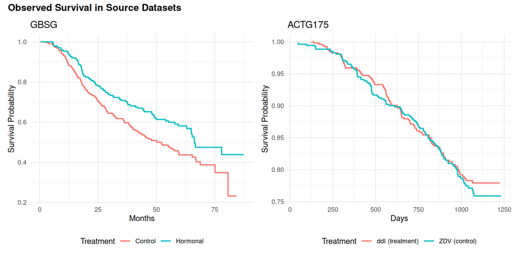

Kaplan-Meier curves in the observed datasets. Left: GBSG (hormonal therapy). Right: ACTG175 (didanosine vs zidovudine).

```r
# ── GBSG KM ──────────────────────────────────────────────────
km_gbsg    <- survfit(Surv(y, status) ~ treat, data = gbsg_df)
km_gbsg_df <- data.frame(
  time = c(km_gbsg$time[1:km_gbsg$strata[1]],
           km_gbsg$time[(km_gbsg$strata[1] + 1):sum(km_gbsg$strata)]),
  surv = c(km_gbsg$surv[1:km_gbsg$strata[1]],
           km_gbsg$surv[(km_gbsg$strata[1] + 1):sum(km_gbsg$strata)]),
  arm = c(
    rep("Control", km_gbsg$strata[1]),
    rep("Hormonal", km_gbsg$strata[2])
  )
)

p_gbsg <- ggplot(km_gbsg_df, aes(x = time, y = surv, colour = arm)) +
  geom_step(linewidth = 0.8) +
  labs(
    title = "GBSG",
    x = "Months", y = "Survival Probability",
    colour = "Treatment"
  ) +
  theme_minimal(base_size = 11) +
  theme(legend.position = "bottom")

# ── ACTG175 KM ───────────────────────────────────────────────
km_actg <- survfit(Surv(time_days, cens) ~ treat, data = actg_df)
km_actg_df <- data.frame(
  time = c(km_actg$time[1:km_actg$strata[1]],
           km_actg$time[(km_actg$strata[1] + 1):sum(km_actg$strata)]),
  surv = c(km_actg$surv[1:km_actg$strata[1]],
           km_actg$surv[(km_actg$strata[1] + 1):sum(km_actg$strata)]),
  arm = c(
    rep("ZDV (control)", km_actg$strata[1]),
    rep("ddI (treatment)", km_actg$strata[2])
  )
)

p_actg <- ggplot(km_actg_df, aes(x = time, y = surv, colour = arm)) +
  geom_step(linewidth = 0.8) +
  labs(
    title = "ACTG175",
    x = "Days", y = "Survival Probability",
    colour = "Treatment"
  ) +
  theme_minimal(base_size = 11) +
  theme(legend.position = "bottom")

p_gbsg + p_actg +
  plot_annotation(
    title = "Observed Survival in Source Datasets",
    theme = theme(plot.title = element_text(face = "bold"))
  )
```

## 2.5 Subgroup Prevalence and Outcome

```r
cat("=== GBSG: Harm subgroup H = {ER-low AND premenopausal} ===\n")
```

```
#> === GBSG: Harm subgroup H = {ER-low AND premenopausal} ===
```

```r
cat("  N(H):", sum(gbsg_df$flag_harm), "/", nrow(gbsg_df),
    sprintf("(%.1f%%)\n", 100 * mean(gbsg_df$flag_harm)))
```

```
#>   N(H): 84 / 686 (12.2%)
```

```r
fit_gbsg_h <- coxph(
  Surv(y, status) ~ treat,
  data = gbsg_df[gbsg_df$flag_harm == 1, ]
)
cat("  Observed HR(H):",
    round(exp(coef(fit_gbsg_h)), 3), "\n\n")
```

```
#>   Observed HR(H): 1.725
```

```r
cat(sprintf(
  "=== ACTG175: Harm subgroup H = {age<=%d AND CD8>%d} ===\n",
  actg_age_cut, actg_cd80_cut
))
```

```
#> === ACTG175: Harm subgroup H = {age<=34 AND CD8>1292} ===
```

```r
cat("  N(H):", sum(actg_df$flag_harm), "/", nrow(actg_df),
    sprintf("(%.1f%%)\n", 100 * mean(actg_df$flag_harm)))
```

```
#>   N(H): 106 / 1046 (10.1%)
```

```r
fit_actg_h <- coxph(
  Surv(time_days, cens) ~ treat,
  data = actg_df[actg_df$flag_harm == 1, ]
)
cat("  Observed HR(H):",
    round(exp(coef(fit_actg_h)), 3), "\n")
```

```
#>   Observed HR(H): 1.867
```

```r
fit_actg_hc <- coxph(
  Surv(time_days, cens) ~ treat,
  data = actg_df[actg_df$flag_harm == 0, ]
)
cat("  Observed HR(Hc):",
    round(exp(coef(fit_actg_hc)), 3), "\n")
```

```
#>   Observed HR(Hc): 0.858
```

# 3 Creating the ACTG175 DGM

Because `setup_gbsg_dgm()` is specific to the GBSG dataset, we use `generate_aft_dgm_flex()` directly. This requires the analyst to supply the prepared dataset, specify all modelling choices, and define the subgroup explicitly.

The key function arguments are:

- `data`: the prepared analysis dataset with `y`, `event`, `treat`, and all `z*` factor columns.
- `factor_vars`: character vector of **all** binary confounder names (here, `z1`–`z12`). These are used as covariates in the AFT model fitted to the observed data.
- `subgroup_vars` / `subgroup_cuts`: define the harm subgroup $H$. `subgroup_cuts` specifies the factor level (here, `1L`) that indicates membership.
- `model`: `"alt"` embeds a treatment-by-subgroup interaction; `"null"` fits a uniform treatment effect (no HTE).
- `k_inter`: multiplier on the interaction coefficient (AFT log-time scale). Higher values produce larger HR(H).
- `k_treat`: multiplier on the main treatment coefficient. Usually `1.0` (retain the observed ITT effect).
- `n_super`: size of the super-population drawn from the fitted AFT model. $5000$ is sufficient for stable HR estimates.

## 3.1 Step 1: Prepare the Analysis Dataset

The DGM function expects columns named by `outcome_var`, `event_var`, and `treatment_var`. We create simple aliases.

```r
# Prepare the ACTG175 data for generate_aft_dgm_flex()
# Column names here must match the *_var arguments below.
dfa        <- actg_df
dfa$y      <- dfa$time_days   # outcome in days
dfa$event  <- dfa$cens        # 1 = event, 0 = censored
# 'treat' already exists from the preparation step above
```

## 3.2 Step 2: Build the DGM (Alternative Hypothesis)

```r
t0 <- proc.time()[3]

dgm_alt <- generate_aft_dgm_flex(
  data            = dfa,
  outcome_var     = "y",
  event_var       = "event",
  treatment_var   = "treat",
  continuous_vars = dgm_continuous_vars,
  factor_vars     = dgm_factor_vars,
  subgroup_vars   = dgm_subgroup_vars,
  subgroup_cuts   = dgm_subgroup_cuts,
  model           = "alt",
  k_inter         = dgm_k_inter_init,
  k_treat         = dgm_k_treat,
  n_super         = dgm_n_super,
  seed            = sim_seed,
  verbose         = TRUE
)
```

```
#>
#> === Subgroup Definitions ===
#>    z1 == 1
#>     Proportion in subgroup: 0.506
#>    z5 == 1
#>     Proportion in subgroup: 0.216
#>
#> Overall subgroup (all conditions met):
#>   Size: 106 out of 1046
#>   Proportion: 0.101
#>
#> === Model Parameters (AFT, log(T)) ===
#> Intercept (mu): 8.039
#> Scale (tau): 0.575
#> Treatment effect: 0.091
#> Interaction effect: -0.566
#>
#> Overall subgroup in super-population (all conditions met):
#>   Proportion: 0.111
#>
#> === Hazard Ratios (super popln) ===
#> Overall HR: 0.935
#> Causal AHR: 0.952
#> Harm subgroup HR: 1.999
#> Harm subgroup AHR: 2.283
#> No-harm subgroup HR: 0.878
#> No-harm subgroup AHR: 0.854
#>
#>  ======================================================================
#>  CENSORING MODEL SELECTION:
#>  MULTIPLE SURVIVAL REGRESSION MODEL COMPARISONS
#> ======================================================================
#>
#> CONVERGENCE SUMMARY ( 4 / 4  converged):
#> --------------------------------------------------
#>
#> Weibull (weibull):
#>   Status:  ✓ Converged
#>   Iterations:  19
#>   Log-likelihood:  -5612.448
```

[output cut: 28 more lines]

```
#> MODEL RANKINGS:
#> --------------------------------------------------
#> By AIC:  Weibull0 > Weibull > LogNormal > LogNormal0
#> By BIC:  Weibull0 > Weibull > LogNormal0 > LogNormal
#>
#> EVIDENCE ASSESSMENT:
#> --------------------------------------------------
#>   Strength:  Moderate evidence
#>   Details:  Top model has 94% of AIC weight
#>
#> FINAL RECOMMENDATION:
#> --------------------------------------------------
#>   Clear winner: Weibull0 (best by both AIC and BIC)
#>   Evidence: Moderate evidence - Top model has 94% of AIC weight
#> ======================================================================
```

```r
# Enrich the DGM with controlled direct effect (CDE) quantities.
# compute_dgm_cde() adds individual-level potential outcomes
# (theta_0, theta_1, loghr_po) to the super-population.  These are
# required by build_estimation_table() and interpret_estimation_table()
# to compute CDE bias and RMSE metrics.  Always call this after
# creating any alternative-hypothesis DGM.
dgm_alt <- compute_dgm_cde(dgm_alt)
dgm_alt <- add_compat_aliases(dgm_alt)

cat("\n=== ACTG175 Alternative DGM ===\n")
```

```
#>
#> === ACTG175 Alternative DGM ===
```

```r
cat("  HR(H):",   round(dgm_alt$hazard_ratios$harm_subgroup,      3), "\n")
```

```
#>   HR(H): 1.999
```

```r
cat("  HR(Hc):",  round(dgm_alt$hazard_ratios$no_harm_subgroup,     3), "\n")
```

```
#>   HR(Hc): 0.878
```

```r
cat("  HR(ITT):", round(dgm_alt$hazard_ratios$overall, 3), "\n")
```

```
#>   HR(ITT): 0.935
```

```r
cat("  AHR(H):",  round(dgm_alt$hazard_ratios$AHR_harm,     3), "\n")
```

```
#>   AHR(H): 2.283
```

```r
cat("  AHR(Hc):", round(dgm_alt$hazard_ratios$AHR_no_harm,    3), "\n")
```

```
#>   AHR(Hc): 0.854
```

```r
cat("  H prevalence:",
    round(100 * mean(dgm_alt$df_super$flag_harm), 1), "%\n")
```

```
#>   H prevalence: 11.1 %
```

```r
timings$dgm_alt <- proc.time()[3] - t0
```

### 3.2.1 Time-Scale Sanity Check

The single most common simulation failure is building the DGM on one time scale (e.g., days) and then passing `analysis_time` in a different scale (e.g., months). This results in a follow-up window far shorter or longer than the DGM event-time distribution, producing either universal censoring or no censoring at all.

The diagnostic below verifies that the DGM’s implied median event time (`exp(mu)`) is in the same ballpark as the observed data and that `analysis_time` is on the correct scale.

```r
observed_median <- median(dfa$y[dfa$event == 1])
dgm_median      <- exp(dgm_alt$model_params$mu)

cat(sprintf("Observed median event time:  %.0f days\n", observed_median))
```

```
#> Observed median event time:  647 days
```

```r
cat(sprintf("DGM implied median (exp(mu)): %.0f days\n", dgm_median))
```

```
#> DGM implied median (exp(mu)): 3101 days
```

```r
cat(sprintf("analysis_time:                %.0f days\n", sim_analysis_time))
```

```
#> analysis_time:                1200 days
```

```r
if (sim_analysis_time < dgm_median * 0.5) {
  warning("analysis_time is much shorter than DGM median -- ",
          "expect heavy administrative censoring!")
}
if (sim_analysis_time > dgm_median * 10) {
  warning("analysis_time is much longer than DGM median -- ",
          "nearly all events will be observed (minimal censoring).")
}
```

## 3.3 Step 3: Calibrate for Target HR

### 3.3.1 Why calibrate?

The DGM’s `k_inter` parameter controls the strength of the treatment-by-subgroup interaction on the AFT (log-time) scale. Because the mapping from `k_inter` to the Cox-model hazard ratio HR(H) is non-linear and depends on the specific covariate distribution, censoring structure, and baseline hazard, we cannot set `k_inter` analytically to achieve a desired HR(H). Instead, we search over a grid of candidate values and select the one that yields an HR(H) closest to the target.

A target HR(H) of 2 is used here because it represents a clinically meaningful level of harm — treatment doubles the hazard in the subgroup — and matches the simulation scenarios in León et al. (2024). Users should choose their target based on the effect size they want their simulation to be powered to detect.

**Note:** `calibrate_k_inter()` automates this process for GBSG-based DGMs. For non-GBSG datasets, the manual grid search shown here is required. This is a known limitation and will be addressed in a future release.

```r
t0 <- proc.time()[3]

cal_results <- data.frame(
  k_inter = cal_k_grid,
  hr_H    = NA_real_,
  hr_Hc   = NA_real_,
  stringsAsFactors = FALSE
)

for (i in seq_along(cal_k_grid)) {
  dgm_k <- tryCatch(
    generate_aft_dgm_flex(
      data            = dfa,
      outcome_var     = "y",
      event_var       = "event",
      treatment_var   = "treat",
      continuous_vars = dgm_continuous_vars,
      factor_vars     = dgm_factor_vars,
      subgroup_vars   = dgm_subgroup_vars,
      subgroup_cuts   = dgm_subgroup_cuts,
      model           = "alt",
      k_inter         = cal_k_grid[i],
      k_treat         = dgm_k_treat,
      n_super         = dgm_n_super,
      seed            = sim_seed,
      verbose         = FALSE
    ),
    error = function(e) NULL
  )

  if (!is.null(dgm_k)) {
    cal_results$hr_H[i]  <- dgm_k$hazard_ratios$harm_subgroup
    cal_results$hr_Hc[i] <- dgm_k$hazard_ratios$no_harm_subgroup
  }
}

# Find k_inter closest to target
cal_valid  <- cal_results[!is.na(cal_results$hr_H), ]
best_idx   <- which.min(abs(cal_valid$hr_H - cal_target_hr))
k_inter_best <- cal_valid$k_inter[best_idx]

cat(sprintf(
  "Calibration: k_inter = %.2f gives HR(H) = %.3f (target: %.1f)\n",
  k_inter_best, cal_valid$hr_H[best_idx], cal_target_hr
))
```

```
#> Calibration: k_inter = 2.00 gives HR(H) = 1.999 (target: 2.0)
```

```r
timings$calibrate <- proc.time()[3] - t0
```

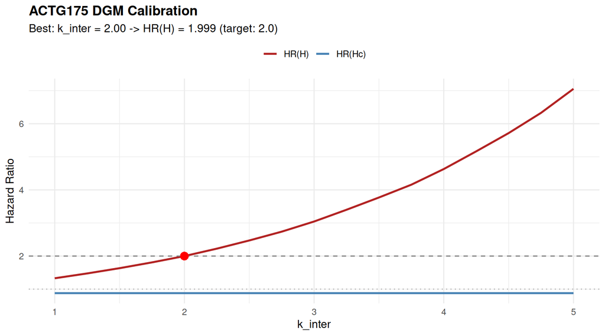

Calibration of k_inter: HR(H) as a function of the interaction parameter.

```r
ggplot(cal_valid, aes(x = k_inter)) +
  geom_line(aes(y = hr_H,  colour = "HR(H)"),  linewidth = 1) +
  geom_line(aes(y = hr_Hc, colour = "HR(Hc)"), linewidth = 1) +
  geom_hline(yintercept = cal_target_hr, linetype = "dashed",
             colour = "grey50") +
  geom_hline(yintercept = 1.0, linetype = "dotted",
             colour = "grey70") +
  geom_point(
    data = cal_valid[best_idx, ],
    aes(x = k_inter, y = hr_H),
    colour = "red", size = 4, shape = 16
  ) +
  scale_colour_manual(
    values = c("HR(H)" = "firebrick", "HR(Hc)" = "steelblue")
  ) +
  labs(
    x = "k_inter",
    y = "Hazard Ratio",
    title = "ACTG175 DGM Calibration",
    subtitle = sprintf(
      "Best: k_inter = %.2f -> HR(H) = %.3f (target: %.1f)",
      k_inter_best, cal_valid$hr_H[best_idx], cal_target_hr
    ),
    colour = NULL
  ) +
  theme_minimal(base_size = 12) +
  theme(legend.position = "top",
        plot.title = element_text(face = "bold"))
```

## 3.4 Step 4: Create Calibrated DGM

```r
t0 <- proc.time()[3]

dgm_calibrated <- generate_aft_dgm_flex(
  data            = dfa,
  outcome_var     = "y",
  event_var       = "event",
  treatment_var   = "treat",
  continuous_vars = dgm_continuous_vars,
  factor_vars     = dgm_factor_vars,
  subgroup_vars   = dgm_subgroup_vars,
  subgroup_cuts   = dgm_subgroup_cuts,
  model           = "alt",
  k_inter         = k_inter_best,
  k_treat         = dgm_k_treat,
  n_super         = dgm_n_super,
  seed            = sim_seed,
  verbose         = TRUE
)
```

```
#>
#> === Subgroup Definitions ===
#>    z1 == 1
#>     Proportion in subgroup: 0.506
#>    z5 == 1
#>     Proportion in subgroup: 0.216
#>
#> Overall subgroup (all conditions met):
#>   Size: 106 out of 1046
#>   Proportion: 0.101
#>
#> === Model Parameters (AFT, log(T)) ===
#> Intercept (mu): 8.039
#> Scale (tau): 0.575
#> Treatment effect: 0.091
#> Interaction effect: -0.566
#>
#> Overall subgroup in super-population (all conditions met):
#>   Proportion: 0.111
#>
#> === Hazard Ratios (super popln) ===
#> Overall HR: 0.935
#> Causal AHR: 0.952
#> Harm subgroup HR: 1.999
#> Harm subgroup AHR: 2.283
#> No-harm subgroup HR: 0.878
#> No-harm subgroup AHR: 0.854
#>
#>  ======================================================================
#>  CENSORING MODEL SELECTION:
#>  MULTIPLE SURVIVAL REGRESSION MODEL COMPARISONS
#> ======================================================================
#>
#> CONVERGENCE SUMMARY ( 4 / 4  converged):
#> --------------------------------------------------
#>
#> Weibull (weibull):
#>   Status:  ✓ Converged
#>   Iterations:  19
#>   Log-likelihood:  -5612.448
```

[output cut: 28 more lines]

```
#> MODEL RANKINGS:
#> --------------------------------------------------
#> By AIC:  Weibull0 > Weibull > LogNormal > LogNormal0
#> By BIC:  Weibull0 > Weibull > LogNormal0 > LogNormal
#>
#> EVIDENCE ASSESSMENT:
#> --------------------------------------------------
#>   Strength:  Moderate evidence
#>   Details:  Top model has 94% of AIC weight
#>
#> FINAL RECOMMENDATION:
#> --------------------------------------------------
#>   Clear winner: Weibull0 (best by both AIC and BIC)
#>   Evidence: Moderate evidence - Top model has 94% of AIC weight
#> ======================================================================
```

```r
# Enrich with CDE potential outcomes (required for estimation tables)
dgm_calibrated <- compute_dgm_cde(dgm_calibrated)
dgm_calibrated <- add_compat_aliases(dgm_calibrated)

cat("\n=== Calibrated ACTG175 DGM ===\n")
```

```
#>
#> === Calibrated ACTG175 DGM ===
```

```r
cat("  HR(H):",   round(dgm_calibrated$hazard_ratios$harm_subgroup,      3), "\n")
```

```
#>   HR(H): 1.999
```

```r
cat("  HR(Hc):",  round(dgm_calibrated$hazard_ratios$no_harm_subgroup,     3), "\n")
```

```
#>   HR(Hc): 0.878
```

```r
cat("  HR(ITT):", round(dgm_calibrated$hazard_ratios$overall, 3), "\n")
```

```
#>   HR(ITT): 0.935
```

```r
timings$dgm_calibrated <- proc.time()[3] - t0
```

## 3.5 Step 5: Create Null DGM

Under `model = "null"`, the treatment effect is uniform across all patients (no treatment effect heterogeneity). The `k_inter` argument is irrelevant under the null and defaults to `1`. Any subgroup detected under the null is a false positive.

```r
t0 <- proc.time()[3]

dgm_null <- generate_aft_dgm_flex(
  data            = dfa,
  outcome_var     = "y",
  event_var       = "event",
  treatment_var   = "treat",
  continuous_vars = dgm_continuous_vars,
  factor_vars     = dgm_factor_vars,
  subgroup_vars   = dgm_subgroup_vars,
  subgroup_cuts   = dgm_subgroup_cuts,
  model           = "null",
  k_treat         = dgm_k_treat,
  n_super         = dgm_n_super,
  seed            = sim_seed,
  verbose         = TRUE
)
```

```
#>
#> === Model Parameters (AFT, log(T)) ===
#> Intercept (mu): 8.08
#> Scale (tau): 0.575
#> Treatment effect: 0.055
#>
#> Overall subgroup in super-population (all conditions met):
#>   Proportion: 0
#>
#> === Hazard Ratios (super popln) ===
#> Overall HR: 0.925
#> Causal AHR: 0.909
#>
#>  ======================================================================
#>  CENSORING MODEL SELECTION:
#>  MULTIPLE SURVIVAL REGRESSION MODEL COMPARISONS
#> ======================================================================
#>
#> CONVERGENCE SUMMARY ( 4 / 4  converged):
#> --------------------------------------------------
#>
#> Weibull (weibull):
#>   Status:  ✓ Converged
#>   Iterations:  19
#>   Log-likelihood:  -5612.448
#>   Scale parameter:  0.1413
#>
#> LogNormal (lognormal):
#>   Status:  ✓ Converged
#>   Iterations:  4
#>   Log-likelihood:  -6051.091
#>   Scale parameter:  0.3376
#>
#> Weibull0 (weibull):
#>   Status:  ✓ Converged
#>   Iterations:  10
#>   Log-likelihood:  -5621.703
#>   Scale parameter:  0.1428
#>
#> LogNormal0 (lognormal):
```

[output cut: 13 more lines]

```
#> MODEL RANKINGS:
#> --------------------------------------------------
#> By AIC:  Weibull0 > Weibull > LogNormal > LogNormal0
#> By BIC:  Weibull0 > Weibull > LogNormal0 > LogNormal
#>
#> EVIDENCE ASSESSMENT:
#> --------------------------------------------------
#>   Strength:  Moderate evidence
#>   Details:  Top model has 94% of AIC weight
#>
#> FINAL RECOMMENDATION:
#> --------------------------------------------------
#>   Clear winner: Weibull0 (best by both AIC and BIC)
#>   Evidence: Moderate evidence - Top model has 94% of AIC weight
#> ======================================================================
```

```r
dgm_null <- add_compat_aliases(dgm_null)

cat("\n=== ACTG175 Null DGM ===\n")
```

```
#>
#> === ACTG175 Null DGM ===
```

```r
cat("  HR(ITT):", round(dgm_null$hazard_ratios$overall, 3), "\n")
```

```
#>   HR(ITT): 0.925
```

```r
timings$dgm_null <- proc.time()[3] - t0
```

# 4 Single Trial Simulation

Before running the full simulation study, we generate a single simulated trial to verify that the pipeline produces sensible data. This is a useful sanity check: the simulated event rate, subgroup prevalence, and ITT HR should be broadly consistent with the DGM parameters.

```r
sim_data <- simulate_from_dgm(
  dgm           = dgm_calibrated,
  n             = single_n,
  rand_ratio    = single_rand_ratio,
  seed          = single_seed,
  analysis_time = sim_analysis_time,
  cens_adjust   = sim_cens_adjust
)

cat("Simulated ACTG175 trial:\n")
```

```
#> Simulated ACTG175 trial:
```

```r
cat("  N =", nrow(sim_data), "\n")
```

```
#>   N = 1000
```

```r
cat("  Events =", sum(sim_data$event_sim),
    sprintf("(%.1f%%)\n", 100 * mean(sim_data$event_sim)))
```

```
#>   Events = 205 (20.5%)
```

```r
cat("  Harm subgroup size =", sum(sim_data$flag_harm),
    sprintf("(%.1f%%)\n", 100 * mean(sim_data$flag_harm)))
```

```
#>   Harm subgroup size = 99 (9.9%)
```

```r
fit_sim <- coxph(Surv(y_sim, event_sim) ~ treat_sim, data = sim_data)
cat("  Estimated ITT HR =", round(exp(coef(fit_sim)), 3), "\n")
```

```
#>   Estimated ITT HR = 1.096
```

## 4.1 Censoring Diagnostic

The `check_censoring_dgm()` function compares the simulated censoring distribution against the observed data used to build the DGM. Large discrepancies suggest a time-scale mismatch or a poorly calibrated censoring model.

```r
check_censoring_dgm(
  sim_data = sim_data,
  dgm      = dgm_calibrated
)
```

```
#>
#> =========================================================
#>   Censoring Diagnostic: DGM Reference vs Simulated
#> =========================================================
#>   DGM censoring type  : weibull
#>   DGM mu_cens         : 6.9668  [exp = 1060.80 time units]
#>   DGM tau_cens        : 0.1428
#>   Reference n (super) : 5000
#>   Simulated n         : 1000
#>
#> --- 1. Censoring Rates ---
#>    Group Ref_rate Sim_rate    Diff
#>  Overall    79.8%    79.5% -0.3 pp
#>    Arm 0    79.0%    80.2% +1.2 pp
#>    Arm 1    80.6%    78.8% -1.8 pp
#>
#> --- 2. Censoring-Time Quantiles (censored subjects only) ---
#>     Ref: y[event == 0]  |  Sim: c_time[event_sim == 0]
#>  Quantile    Ref     Sim Ratio
#>       25%  962.0  869.84 0.904
#>       50% 1057.0  991.64 0.938
#>       75% 1112.0 1095.90 0.986
#>       90% 1152.9 1177.77 1.022
#>
#> --- 3. KM Median Censoring Time (reversed event indicator) ---
#>    Group Ref_median Sim_median Ratio
#>  Overall       1064  1004.3562 0.944
#>    Arm 0       1055  1010.8293 0.958
#>    Arm 1       1069   999.6909 0.935
#>
#> --- 4. Implied Time-Scale Check ---
#>   exp(params$mu)          = 3100.93  [median outcome time, DGM scale]
#>   exp(params$censoring$mu)= 1060.80  [median censoring time, DGM scale]
#>   If these values are implausibly large relative to your
#>   analysis_time, the DGM was likely built on a different time
#>   scale (e.g. days vs months).
#>
#> [OK] No substantial discrepancies detected.
#> =========================================================
```

# 5 Running Simulation Studies

## 5.1 Setup

```r
plan(multisession, workers = n_workers)
cat("Using", n_workers, "parallel workers\n")
```

```
#> Using 120 parallel workers
```

```r
# ── Candidate variable set ────────────────────────────────────
# confounders_base tells run_simulation_analysis() which columns in
# the simulated data to pass to ForestSearch and GRF as candidate
# subgroup-defining variables.  These must:
#   1. Be present in the super-population (dgm$df_super)
#   2. Be binary factors (0/1) for ForestSearch
#   3. Match the names used in factor_vars when building the DGM
#
# If your dataset uses different variable names (e.g. "age_bin",
# "cd4_low"), update BOTH factor_vars (in the DGM call) and
# confounders_base (here) to match.
confounders_actg <- dgm_factor_vars

# ── ForestSearch parameters ───────────────────────────────────
# These are passed to run_simulation_analysis() and forwarded to
# forestsearch().  The annotations below explain each parameter
# and when you might change it for your own study.
fs_params <- list(
  # Column name mappings — must match simulate_from_dgm() output
  outcome.name           = "y_sim",
  event.name             = "event_sim",
  treat.name             = "treat_sim",
  id.name                = "id",

  # Variable screening flags
  use_lasso              = TRUE,    # LASSO pre-screening (recommended)
  use_grf                = TRUE,    # GRF pre-screening (recommended)

  # Subgroup detection thresholds (see Leon et al. 2024, Section 3)
  # c1: a candidate subgroup must have HR > hr.threshold to be flagged.
  # Increase for more conservative detection; decrease for more power.
  hr.threshold           = fs_hr_threshold,
  # c2: in each bootstrap replicate, the subgroup HR must exceed this
  # value.  Typically set to 1.0 (any harm signal).
  hr.consistency         = fs_hr_consistency,
  # The proportion of bootstrap replicates in which the subgroup HR
  # exceeds c2.  The paper default is 0.90.
  pconsistency.threshold = fs_pconsistency_thresh,

  # Computational and sample-size constraints
  fs.splits              = fs_splits,    # Bootstrap replicates (400 is default)
  n.min                  = fs_n_min,     # Minimum subgroup size (both arms)
  d0.min                 = fs_d0_min,    # Minimum events, control arm
  d1.min                 = fs_d1_min,    # Minimum events, treatment arm
  maxk                   = fs_maxk,      # Max subgroup-defining variables
  by.risk                = fs_by_risk,   # Risk-table granularity (time units)
  vi.grf.min             = fs_vi_grf_min, # GRF variable importance threshold

  # Two-stage estimation: after identifying a subgroup, re-estimates
  # the treatment effect using an independent hold-out sample.
  # Recommended for bias correction.
  use_twostage           = TRUE,
  twostage_args          = list(),

  # Inner parallelism: ForestSearch runs sequentially within each
  # worker.  The outer loop (foreach) parallelises across replicates.
  parallel_args          = list(
    plan = "sequential", workers = 1, show_message = FALSE
  )
)

# ── Simulation configuration ─────────────────────────────────
sim_config <- list(
  n_sample      = sim_n_sample,
  analysis_time = sim_analysis_time,
  cens_adjust   = sim_cens_adjust
)
```

## 5.2 Alternative Hypothesis Simulations

```r
cat("Running", nsims_alt, "simulations under H1...\n")
```

```
#> Running 100 simulations under H1...
```

```r
t0 <- proc.time()[3]

results_alt <- foreach(
  sim = seq_len(nsims_alt),
  .combine = rbind,
  .errorhandling = "remove",
  .options.future = list(
    packages = c("forestsearch", "survival", "data.table", "future"),
    seed = TRUE
  )
) %dofuture% {
  # Reset plan inside workers to prevent nested parallelism.
  # Each worker runs ForestSearch sequentially; the outer foreach
  # loop parallelises across simulation replicates.
  future::plan("sequential")
  run_simulation_analysis(
    sim_id           = sim,
    dgm              = dgm_calibrated,
    n_sample         = sim_config$n_sample,
    analysis_time    = sim_config$analysis_time,
    cens_adjust      = sim_config$cens_adjust,
    confounders_base = confounders_actg,
    cox_formula_adj  = cox_formula_adj,
    n_add_noise      = sim_n_noise,
    run_fs           = run_fs,
    run_fs_grf       = run_fs_grf,
    run_grf          = run_grf,
    fs_params        = fs_params,
    verbose          = FALSE
  )
}

timings$sims_alt <- proc.time()[3] - t0
cat("Completed in", round(timings$sims_alt / 60, 1), "minutes\n")
```

```
#> Completed in 0.4 minutes
```

```r
cat("Results:", nrow(results_alt), "rows\n")
```

```
#> Results: 200 rows
```

## 5.3 Null Hypothesis Simulations

```r
cat("Running", nsims_null, "simulations under H0...\n")
```

```
#> Running 100 simulations under H0...
```

```r
t0 <- proc.time()[3]

results_null <- foreach(
  sim = seq_len(nsims_null),
  .combine = rbind,
  .errorhandling = "remove",
  .options.future = list(
    packages = c("forestsearch", "survival", "data.table", "future"),
    seed = TRUE
  )
) %dofuture% {
  # Reset plan inside workers to prevent nested parallelism.
  future::plan("sequential")
  run_simulation_analysis(
    sim_id           = sim,
    dgm              = dgm_null,
    n_sample         = sim_config$n_sample,
    analysis_time    = sim_config$analysis_time,
    cens_adjust      = sim_config$cens_adjust,
    confounders_base = confounders_actg,
    cox_formula_adj  = cox_formula_adj,
    n_add_noise      = sim_n_noise,
    run_fs           = run_fs,
    run_fs_grf       = run_fs_grf,
    run_grf          = run_grf,
    fs_params        = fs_params,
    verbose          = FALSE
  )
}

timings$sims_null <- proc.time()[3] - t0
cat("Completed in", round(timings$sims_null / 60, 1), "minutes\n")
```

```
#> Completed in 0.3 minutes
```

# 6 Results

## 6.1 Metrics Glossary

The operating-characteristics tables below report three groups of metrics:

- **detection**: the proportion of simulations where ForestSearch (or GRF) identifies *any* subgroup ($\texttt{any.H} = 1$). Under the alternative, this is detection power; under the null, it is the false-positive rate (type I error).
- **classification**: among simulations where a subgroup was detected, how well the identified subgroup $\hat{H}$ overlaps with the true subgroup $H$. Includes sensitivity (proportion of true $H$ members captured), specificity (proportion of $H^c$ members correctly excluded), and positive predictive value (PPV, proportion of $\hat{H}$ that truly belongs to $H$).
- **cde_estimates**: bias and root-mean-square error (RMSE) of the controlled direct effect (CDE) estimator for the treatment effect within $\hat{H}$ and $\hat{H}^c$, relative to the true DGM values. The CDE is defined at the individual level via potential outcomes and represents the causal estimand (see León et al. 2024, Section 2.2).

## 6.2 Operating Characteristics Under H1

```r
t0 <- proc.time()[3]

format_oc_results(
  results_alt,
  metrics   = c("detection", "classification", "cde_estimates"),
  digits    = 2,
  digits_hr = 2,
  title     = "ACTG175: Identification Properties (HTEs)",
  subtitle  = sprintf(
    "n = %d, %d sims, HR(H) = %.2f, HR(Hc) = %.2f",
    sim_config$n_sample, nsims_alt,
    dgm_calibrated$hazard_ratios$harm_subgroup,
    dgm_calibrated$hazard_ratios$no_harm_subgroup
  )
)
```

ACTG175: Identification Properties (HTEs)

n = 1000, 100 sims, HR(H) = 2.00, HR(Hc) = 0.88

| Method | Sims | Found | Classification Sen | Classification Spec | Classification PPV | Classification NPV | Controlled Direct Effects θ‡(H) | Controlled Direct Effects θ‡(Hᶜ) | Controlled Direct Effects θ‡(Ĥ) | Controlled Direct Effects θ‡(Ĥᶜ) |
| --- | --- | --- | --- | --- | --- | --- | --- | --- | --- | --- |
| FS | 100 | 0.71 | 0.69 | 0.87 | 0.47 | 0.96 | 2.28 | 0.85 | 1.53 | 0.92 |
| GRF | 100 | 0.99 | 0.48 | 0.84 | 0.33 | 0.93 | 2.28 | 0.85 | 1.33 | 0.96 |

```r
build_estimation_table(
  results         = results_alt,
  dgm             = dgm_calibrated,
  analysis_method = "FS",
  subtitle = sprintf(
    "ACTG175 DGM | n = %d, %d sims",
    sim_config$n_sample, nsims_alt
  ),
  font_size = 16
)
```

Estimation Properties

ACTG175 DGM | n = 1000, 100 sims (FS: 71/100 (71%) estimable)

|  | Avg | SD | Min | Max | b‡ (%) | b† (%) |
| --- | --- | --- | --- | --- | --- | --- |
| Ĥ: 71 estimable, avg \|Ĥ\| = 192, θ†(H) = 2, θ‡(H) = 2.28 |  |  |  |  |  |  |
| θ̂(Ĥ) | 2.24 | 0.42 | 1.59 | 3.63 | -1.86 | 12.09 |
| âhr(Ĥ) | 1.40 | 0.41 | 0.85 | 2.28 | NA | -38.62 |
| θ‡(Ĥ) | 1.53 | 0.39 | 0.85 | 2.28 | NA | -33.15 |
| Ĥᶜ: avg \|Ĥᶜ\| = 808, θ†(Hᶜ) = 0.88, θ‡(Hᶜ) = 0.85 |  |  |  |  |  |  |
| θ̂(Ĥᶜ) | 0.87 | 0.13 | 0.60 | 1.17 | 1.72 | -1.14 |
| âhr(Ĥᶜ) | 0.89 | 0.04 | 0.85 | 1.01 | NA | 4.41 |
| θ‡(Ĥᶜ) | 0.92 | 0.06 | 0.85 | 1.09 | NA | 7.30 |

θ̂(Ĥ) = plugin Cox HR in identified subgroup; θ̂*(Ĥ) = bootstrap bias-corrected; âhr(Ĥ) = average hazard ratio in identified subgroup; b† = bias relative to marginal HR θ† (causal truth); θ‡(Ĥ) = controlled direct effect in identified subgroup; b‡ = bias relative to CDE θ‡

```r
timings$summarize_alt <- proc.time()[3] - t0
```

### 6.2.1 Interpretation

```r
interpret_estimation_table(
  results_alt, dgm_calibrated,
  analysis_method = "FS",
  scenario = "alt"
)
```

Under the alternative hypothesis (true HR(H) = 2, true HR(Hc) = 0.88), 71 of 100 simulations (71.0%) identified a subgroup using FS. The identified subgroup averaged 192 patients (complement: 808).

The naive Cox HR in the identified subgroup averaged 2.24 (SD = 0.42), corresponding to 12.1% relative bias versus the true HR(H) = 2. In the complement, the estimate averaged 0.87 (-1.1% bias vs. true HR(Hc) = 0.88).

Relative to the controlled direct effect (CDE) truth theta-ddagger(H) = 2.28, the naive plugin shows -1.9% relative bias.

The average hazard ratio (AHR) in the identified subgroup averaged 1.4 (-38.6% relative bias vs. true AHR(H) = 2.28); in the complement, 0.89 (4.4% bias vs. true AHR(Hc) = 0.85).

## 6.3 Operating Characteristics Under H0

```r
t0 <- proc.time()[3]

format_oc_results(
  results_null,
  metrics  = c("detection", "classification"),
  digits   = 2,
  title    = "ACTG175: Type I Error (Null)",
  subtitle = sprintf(
    "n = %d, %d sims, HR(ITT) = %.2f",
    sim_config$n_sample, nsims_null,
    dgm_null$hazard_ratios$overall
  )
)
```

ACTG175: Type I Error (Null)

n = 1000, 100 sims, HR(ITT) = 0.92

| Method | Sims | Found | Classification Sen | Classification Spec | Classification PPV | Classification NPV |
| --- | --- | --- | --- | --- | --- | --- |
| FS | 100 | 0.36 | - | 0.72 | 0.00 | 1.00 |
| GRF | 100 | 0.98 | - | 0.79 | 0.00 | 1.00 |

```r
timings$summarize_null <- proc.time()[3] - t0
```

## 6.4 Classification Table

```r
scenario_list <- list(
  null = list(
    results    = results_null,
    label      = "ACTG",
    n_sample   = sim_config$n_sample,
    dgm        = dgm_null,
    hypothesis = "null"
  ),
  alt = list(
    results    = results_alt,
    label      = "ACTG",
    n_sample   = sim_config$n_sample,
    dgm        = dgm_calibrated,
    hypothesis = "alt"
  )
)

build_classification_table(
  scenario_results = scenario_list,
  analyses = sort(unique(c(
    unique(results_null$analysis),
    unique(results_alt$analysis)
  ))),
  digits    = 2,
  font_size = 16,
  title     = "ACTG175: Subgroup Identification and Classification",
  n_sims    = nsims_alt
)
```

ACTG175: Subgroup Identification and Classification

Across 100 simulations per scenario

|  | FS | GRF |
| --- | --- | --- |
| ACTG Null: N=1000, theta(ITT) = 0.92 |  |  |
| any(H) | 0.36 | 0.98 |
| sens(Hc) | 0.72 | 0.79 |
| ppv(Hc) | 1.00 | 1.00 |
| avg\|H\| | 285.00 | 208.00 |
| ACTG Alt: N=1000, p_H=NA%, theta(H)=2, theta(Hc)=0.88, theta(ITT)=0.94 |  |  |
| any(H) | 0.71 | 0.99 |
| sens(H) | 0.69 | 0.48 |
| sens(Hc) | 0.87 | 0.84 |
| ppv(H) | 0.47 | 0.33 |
| ppv(Hc) | 0.96 | 0.93 |
| avg\|H\| | 192.00 | 195.00 |

# 7 Theoretical Detection Probability

The detection probability is the theoretical power of ForestSearch’s bootstrap consistency rule to flag a subgroup with a given HR, given the expected subgroup size and censoring proportion. This curve provides a reference for interpreting the empirical detection rate observed in the simulation.

The `method = "cubature"` argument uses numerical integration (via the `cubature` package) to compute the joint probability that the subgroup HR exceeds `hr.threshold` (c1) and that the proportion of bootstrap replicates exceeding `hr.consistency` (c2) is at least `pconsistency.threshold`. An alternative `method = "normal"` uses a normal approximation.

```r
n_sg_expected <- sim_config$n_sample *
  mean(dgm_calibrated$df_super$flag_harm)
prop_cens <- mean(results_alt$p.cens)

cat("Expected subgroup size:", round(n_sg_expected), "\n")
```

```
#> Expected subgroup size: 111
```

```r
cat("Censoring proportion:",   round(prop_cens, 3), "\n")
```

```
#> Censoring proportion: 0.792
```

```r
cat("True HR(H):",             round(dgm_calibrated$hazard_ratios$harm_subgroup, 3), "\n")
```

```
#> True HR(H): 1.999
```

```r
prob_detect <- compute_detection_probability(
  theta          = dgm_calibrated$hazard_ratios$harm_subgroup,
  n_sg           = round(n_sg_expected),
  prop_cens      = prop_cens,
  hr_threshold   = fs_params$hr.threshold,
  hr_consistency = fs_params$hr.consistency,
  method         = "cubature"
)

cat("\nTheoretical P(detect):", round(prob_detect, 3), "\n")
```

```
#>
#> Theoretical P(detect): 0.756
```

```r
cat("Empirical FS:",
    round(mean(results_alt[
      results_alt$analysis == "FS", "any.H"
    ]), 3), "\n")
```

```
#> Empirical FS: NA
```

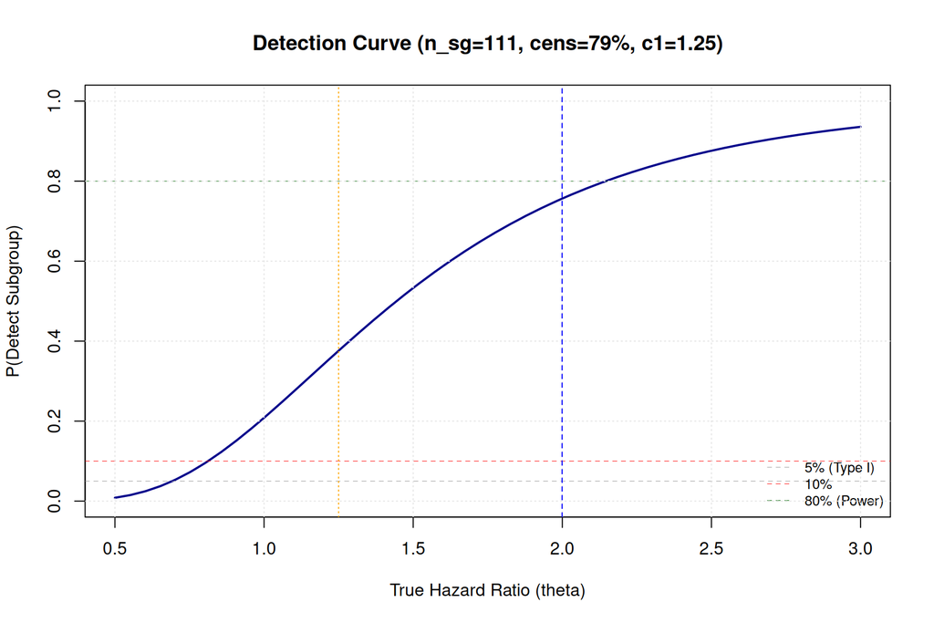

```r
# Generate curve
detection_curve <- generate_detection_curve(
  theta_range       = det_theta_range,
  n_points          = det_n_points,
  n_sg              = round(n_sg_expected),
  prop_cens         = prop_cens,
  hr_threshold      = fs_params$hr.threshold,
  hr_consistency    = fs_params$hr.consistency,
  include_reference = TRUE,
  verbose           = FALSE
)

plot_detection_curve(
  detection_curve,
  add_reference_lines = TRUE,
  add_threshold_line  = TRUE,
  title = sprintf(
    "Detection Curve (n_sg=%d, cens=%.0f%%, c1=%.2f)",
    round(n_sg_expected), 100 * prop_cens,
    fs_params$hr.threshold
  )
)

abline(v = dgm_calibrated$hazard_ratios$harm_subgroup, lty = 2, col = "blue")
```